# STAT 385 - Homework 6

Apurva Chakravorty - achakr9

Due 11:59 PM, 3/30/2020

## Submit your homework

Make sure you check the following requirements when submitting your homework:

- Put your name - your NetID as the author info at the top of the Rmd file.
- After pushing the latest commit to Git, check if the changes are reflected on [github.com](https://github.com/).
  - DO NOT directly upload to github.com! That is not how we push a commit in this class!

Failure to meet the above requirements will negatively impact your grade.

## Before you start

- **For all plots in this homework, you have to use the functions from the ggplot2 package**.
  - If you use base R plotting functions, your answers will NOT be graded.
- The maximum possible points for this homework is 70.
  - Make sure you answer all the questions!

## Dataset: diamonds from the ggplot2 package

The ggplot2 package include many interesting datasets. We looked at `mpg` in lecture this week. Now, we will explore the `diamonds` dataset. This data contains the prices and other attributes of almost 54,000 diamonds.

```r
library(tidyverse)
str(diamonds)
```

```
## Classes 'tbl_df', 'tbl' and 'data.frame':    53940 obs. of  10 variables:
##  $ carat  : num  0.23 0.21 0.23 0.29 0.31 0.24 0.24 0.26 0.22 0.23 ...
##  $ cut    : Ord.factor w/ 5 levels "Fair"<"Good"<..: 5 4 2 4 2 3 3 3 1 3 ...
##  $ color  : Ord.factor w/ 7 levels "D"<"E"<"F"<"G"<..: 2 2 2 6 7 7 6 5 2 5 ...
##  $ clarity: Ord.factor w/ 8 levels "I1"<"SI2"<"SI1"<..: 2 3 5 4 2 6 7 3 4 5 ...
##  $ depth  : num  61.5 59.8 56.9 62.4 63.3 62.8 62.3 61.9 65.1 59.4 ...
##  $ table  : num  55 61 65 58 58 57 57 55 61 61 ...
##  $ price  : int  326 326 327 334 335 336 336 337 337 338 ...
##  $ x      : num  3.95 3.89 4.05 4.2 4.34 3.94 3.95 4.07 3.87 4 ...
##  $ y      : num  3.98 3.84 4.07 4.23 4.35 3.96 3.98 4.11 3.78 4.05 ...
##  $ z      : num  2.43 2.31 2.31 2.63 2.75 2.48 2.47 2.53 2.49 2.39 ...
```

- Run `?diamonds` to know what each variable presents.

### Scatterplot

- There are 4 parts to this exercise: each part worths 5 points.
- **(a)** Graph a scatterplot of `price` vs `carat`.
  - `price` as the $y$-axis and `carat` as the $x$-axis.

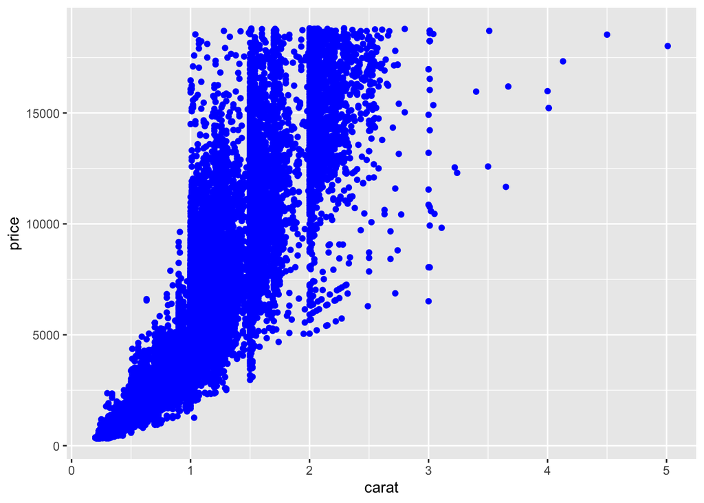

```r
ggplot(data = diamonds) +
  geom_point(mapping = aes(x = carat, y = price), color = 'blue')
```

- **(b) With the above graph**, adjust the transparency level of ALL the points so we can see clearly where the clusters are:

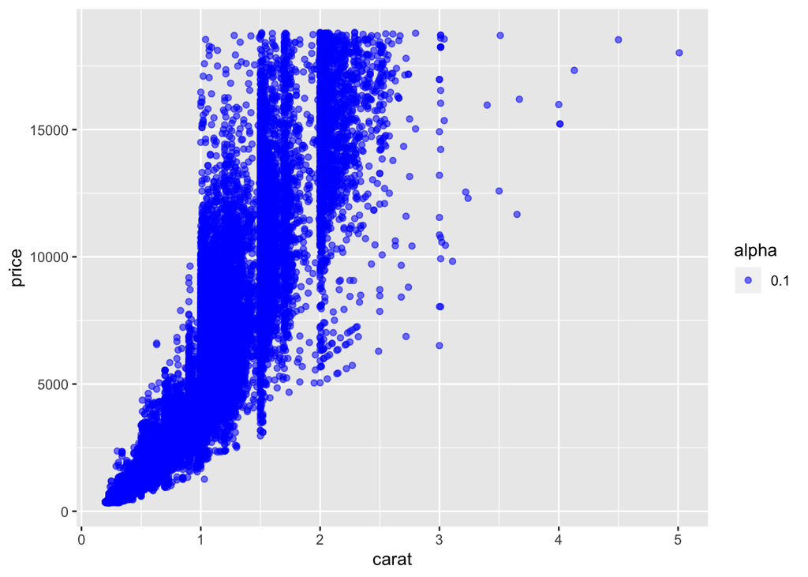

```r
ggplot(data = diamonds) +
  geom_point(mapping = aes(x = carat, y = price, alpha = 0.1), color = 'blue')
```

- **(c) Now create a new plot**, graph a scatterplot of `price` vs `carat`, and color the points BY the quality of the cut (`cut`)!
  - Don’t change the transparency level of the points.

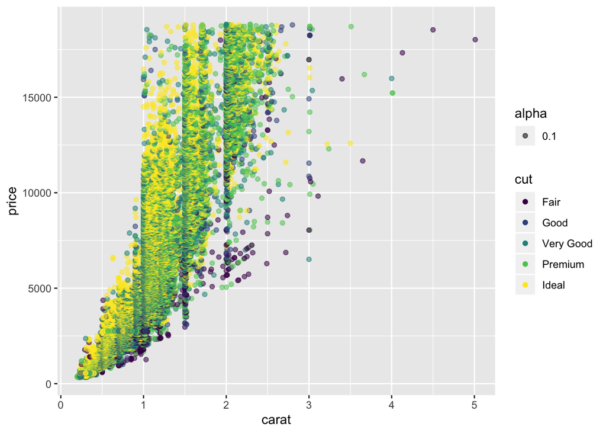

```r
ggplot(data = diamonds) +
  geom_point(mapping = aes(x = carat, y = price, color = cut, alpha = 0.1))
```

- **(d) What can you conclude based on the above graph?**
  - **Most cuts of 1-2 carat diamonds are very good, premium or ideal. With higher carat diamonds, the quality of the cut seems to go down to fair or good. As the quality of the cut gets better, the price of the diamond goes up, even if the carat is low. For very high carat diamonds, the price is high, regardless of the quality of the cut.**

### Boxplot

- There are 3 parts to this exercise: each part worths 5 points.
- **(a)** Graph a boxplot of `carat` vs `cut`.
  - `carat` as the $y$-axis and `cut` as the $x$-axis.

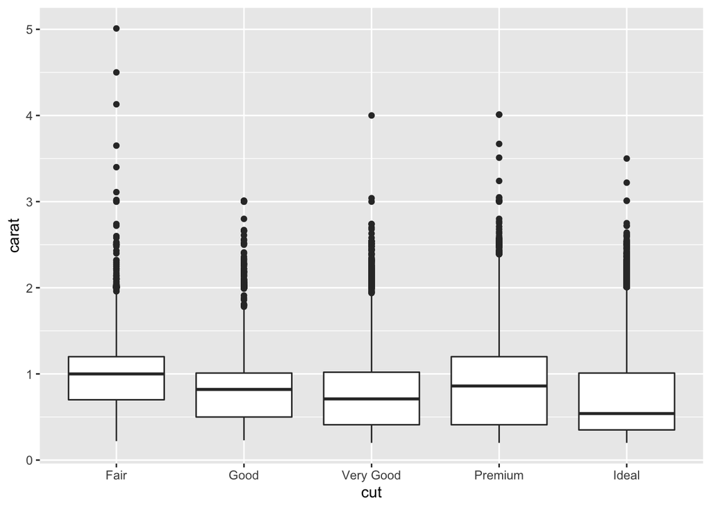

```r
ggplot(data = diamonds) +
  geom_boxplot(mapping = aes(x = cut, y = carat))
```

- **(b) With the plot above**, rotate it so `cut` is on the $y$-axis and `carat` is on the $x$-axis.
  - Make sure the plot is still a boxplot.

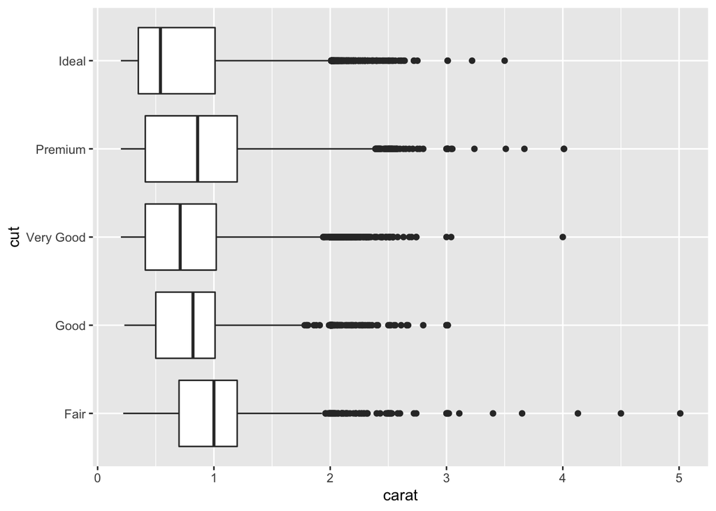

```r
ccbox <- ggplot(data = diamonds) +
  geom_boxplot(mapping = aes(x = cut, y = carat))
ccbox + coord_flip()
```

- **(c) With the plot from (b)**, color the boxplot dark blue.

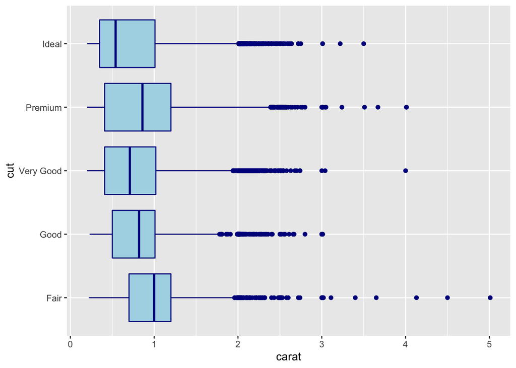

```r
ccbox2 <- ggplot(data = diamonds) +
  geom_boxplot(mapping = aes(x = cut, y = carat), color = "darkblue", fill = "lightblue")
ccbox2 + coord_flip()
```

### Histogram

- There are 3 parts to this exercise: each part worths 5 points.
- **(a)** Graph a histogram of `price`.

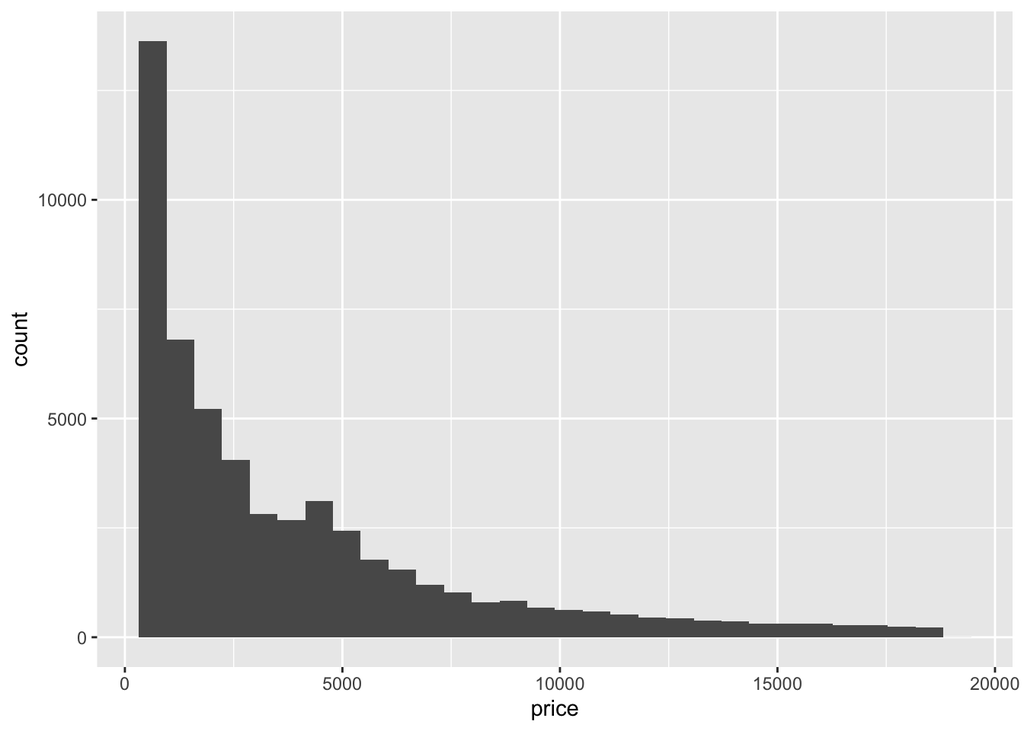

```r
ggplot(data = diamonds) +
  geom_histogram(mapping = aes(x = price))
```

- **(b) With the plot above**, color the bars dark orange.

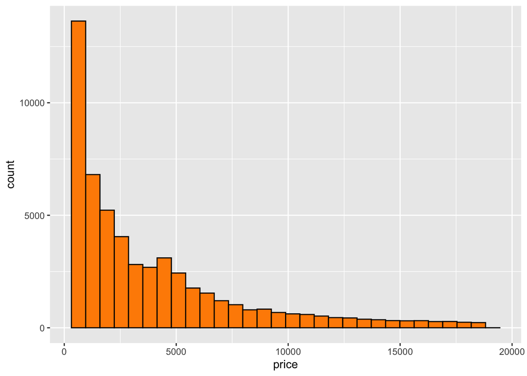

```r
ggplot(data = diamonds) +
  geom_histogram(mapping = aes(x = price), color = "black", fill = "darkorange")
```

- **(c) With the plot from (b)**, change the number of bins to 50.

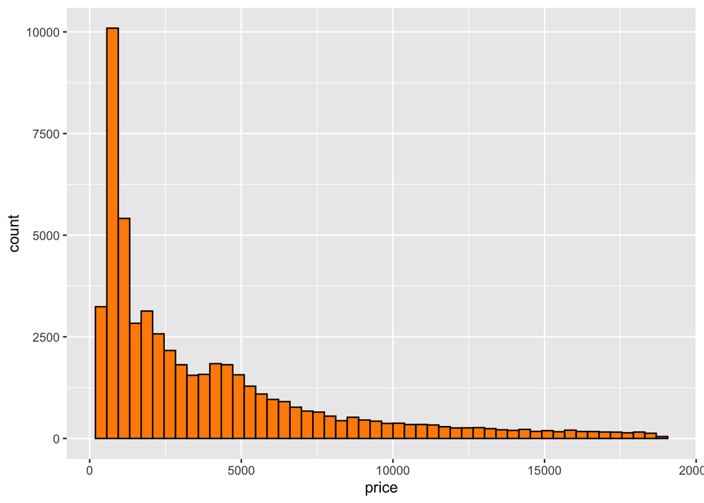

```r
ggplot(data = diamonds) +
  geom_histogram(mapping = aes(x = price), color = "black", fill = "darkorange", bins = 50)
```

## Dataset: 2015 Flight Delays and Cancellations Data

In this exercise, we continue to work with the 2015 Flight Delays and Cancellations Data provided by the U.S. Department of Transportation. This is a huge dataset availalbe on [Kaggle](https://www.kaggle.com/usdot/flight-delays#airports.csv). But for us, we will only take a look at flights **flying out** from O’Hare International Airport (ORD) in January, 2015.

### Load data

- I have filtered out the data specific to O’Hare and stored it in `ohare_jan.csv`. This filtered data is available at the URL: https://nkha149.github.io/stat385-sp2020/files/data/ohare_jan.csv.

```r
flights <- read_csv(file = "https://nkha149.github.io/stat385-sp2020/files/data/ohare_jan.csv")
summary(flights)
```

```
##       YEAR          MONTH        DAY        DAY_OF_WEEK      AIRLINE
##  Min.   :2015   Min.   :1   Min.   : 1.0   Min.   :1.000   Length:23484
##  1st Qu.:2015   1st Qu.:1   1st Qu.: 8.0   1st Qu.:2.000   Class :character
##  Median :2015   Median :1   Median :16.0   Median :4.000   Mode  :character
##  Mean   :2015   Mean   :1   Mean   :15.9   Mean   :4.007
##  3rd Qu.:2015   3rd Qu.:1   3rd Qu.:24.0   3rd Qu.:6.000
##  Max.   :2015   Max.   :1   Max.   :31.0   Max.   :7.000
##
##  FLIGHT_NUMBER  ORIGIN_AIRPORT     DESTINATION_AIRPORT SCHEDULED_DEPARTURE
##  Min.   :   3   Length:23484       Length:23484        Min.   : 500
##  1st Qu.:1142   Class :character   Class :character    1st Qu.: 957
##  Median :2932   Mode  :character   Mode  :character    Median :1345
##  Mean   :2814                                          Mean   :1380
##  3rd Qu.:4147                                          3rd Qu.:1749
##  Max.   :6533                                          Max.   :2300
##
##  DEPARTURE_TIME DEPARTURE_DELAY     TAXI_OUT      SCHEDULED_TIME
##  Min.   :   1   Min.   :-28.00   Min.   :  1.00   Min.   : 40.0
##  1st Qu.:1009   1st Qu.: -4.00   1st Qu.: 13.00   1st Qu.: 77.0
##  Median :1401   Median :  1.00   Median : 16.00   Median :113.0
##  Mean   :1397   Mean   : 19.96   Mean   : 19.87   Mean   :126.5
##  3rd Qu.:1805   3rd Qu.: 24.00   3rd Qu.: 21.00   3rd Qu.:156.0
##  Max.   :2400   Max.   :749.00   Max.   :152.00   Max.   :559.0
##  NA's   :1059   NA's   :1059     NA's   :1110
##   ELAPSED_TIME      TAXI_IN        SCHEDULED_ARRIVAL  ARRIVAL_TIME
##  Min.   : 30.0   Min.   :  1.000   Min.   :   1      Min.   :   1
##  1st Qu.: 77.0   1st Qu.:  4.000   1st Qu.:1210      1st Qu.:1159
##  Median :110.0   Median :  5.000   Median :1611      Median :1601
##  Mean   :125.3   Mean   :  6.585   Mean   :1581      Mean   :1548
##  3rd Qu.:154.0   3rd Qu.:  7.000   3rd Qu.:1954      3rd Qu.:1947
##  Max.   :607.0   Max.   :127.000   Max.   :2359      Max.   :2400
##  NA's   :1168    NA's   :1139                        NA's   :1139
##  ARRIVAL_DELAY       DIVERTED          CANCELLED       CANCELLATION_REASON
##  Min.   :-61.00   Min.   :0.000000   Min.   :0.00000   Length:23484
##  1st Qu.:-11.00   1st Qu.:0.000000   1st Qu.:0.00000   Class :character
##  Median :  0.00   Median :0.000000   Median :0.00000   Mode  :character
##  Mean   : 17.02   Mean   :0.002129   Mean   :0.04761
##  3rd Qu.: 26.00   3rd Qu.:0.000000   3rd Qu.:0.00000
##  Max.   :751.00   Max.   :1.000000   Max.   :1.00000
##  NA's   :1168
##  AIR_SYSTEM_DELAY SECURITY_DELAY   AIRLINE_DELAY    LATE_AIRCRAFT_DELAY
##  Min.   :  0.00   Min.   : 0.000   Min.   :  0.00   Min.   :  0.00
##  1st Qu.:  0.00   1st Qu.: 0.000   1st Qu.:  0.00   1st Qu.:  0.00
##  Median :  5.00   Median : 0.000   Median :  0.00   Median :  0.00
##  Mean   : 15.09   Mean   : 0.012   Mean   : 17.73   Mean   : 22.14
##  3rd Qu.: 21.00   3rd Qu.: 0.000   3rd Qu.: 21.00   3rd Qu.: 28.00
##  Max.   :484.00   Max.   :57.000   Max.   :674.00   Max.   :560.00
##  NA's   :16181    NA's   :16181    NA's   :16181    NA's   :16181
##  WEATHER_DELAY
##  Min.   :  0.00
##  1st Qu.:  0.00
##  Median :  0.00
##  Mean   : 12.13
##  3rd Qu.:  8.00
##  Max.   :486.00
##  NA's   :16181
```

### Using `dplyr` and `ggplot2` together

- For this exercise, you will need to:
  - Graph a plot that can be used to answer the question.
  - Determine the type of plot that is needed.
  - (You might need to) Manipulate the data to get the specific information that you want.
- There are 2 parts to this exercise: each part worths 10 points.
- **(a)** How does the **average** departure delay time differ among days of the week?

```r
depdelay <- flights %>%
  group_by(DAY_OF_WEEK) %>%
  summarise(avgdepdelay = mean(DEPARTURE_DELAY, na.rm = TRUE))

depdelay
```

```
## # A tibble: 7 x 2
##   DAY_OF_WEEK avgdepdelay
##         <dbl>       <dbl>
## 1           1        28.4
## 2           2        19.6
## 3           3        16.5
## 4           4        20.8
## 5           5        14.9
## 6           6        12.4
## 7           7        29.5
```

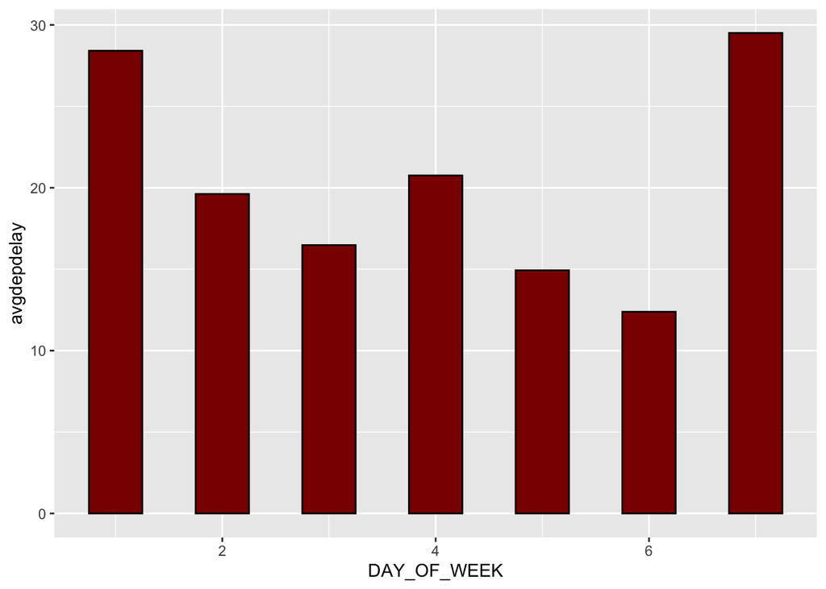

```r
ggplot(data = depdelay) +
  geom_bar(mapping = aes(x = DAY_OF_WEEK, y = avgdepdelay), stat = "identity", color = "black", fill = "darkred", width = 0.5)
```

*The average departure delay time differs throughout the week. The lowest delays occur on Saturday (Day 6) and the longest delays occur on Sunday (Day 7). Monday (Day 1) also has comparably long delays. We can look further into the number of flights per day to see how air traffic might affect delay times.*

- **(b)** Airlines are grouped into different terminals. There is a belief that certain terminals have better taxing out time. How does **median** taxi out time differ among diferrent airlines?

```r
termtaxi <- flights %>%
  group_by(AIRLINE) %>%
  summarise(medtaxiout = median(TAXI_OUT, na.rm = TRUE))
termtaxi
```

```
## # A tibble: 12 x 2
##    AIRLINE medtaxiout
##    <chr>        <dbl>
##  1 AA            14
##  2 AS            18
##  3 B6            20
##  4 DL            17
##  5 EV            16
##  6 F9            19.5
##  7 MQ            16
##  8 NK            15
##  9 OO            19
## 10 UA            17
## 11 US            17
## 12 VX            14
```

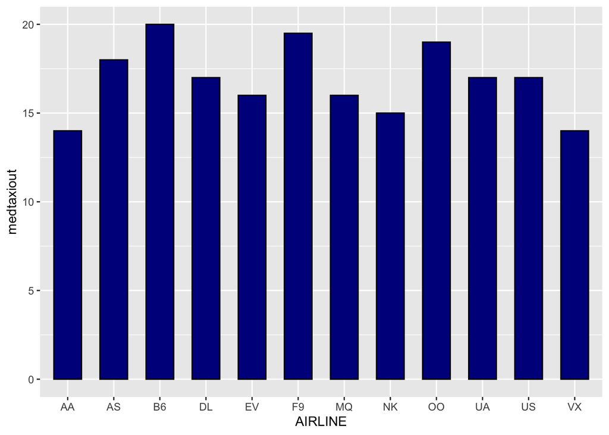

```r
ggplot(data = termtaxi) +
  geom_histogram(mapping = aes(x = AIRLINE, y = medtaxiout), stat = "identity", color = "black", fill = "darkblue", width = 0.6)
```

*The mediam taxi out time differs between 14 minutes and 20 across all O’Hare airlines, with VX and AA having the lowest median times and B6 having the highest. To analyze it further, we could look at the median or average number of flights booked per airline to compare. We could also then organize by terminal to determine whether some terminals have higher medians than the others.*